# STA 100 Discussion 5

Gianni Spiga

2023-10-26

## R Problems

### 1. Generate data sets of $n$ observations from normally distributed random variables using $n = 10, 100, 1000, 10000$.

Generate data sets of $n$ observations from normally distributed random variables using $n = 10, 100, 1000, 10000$.

```r
# By setting a seed, we are able to make sure Rstudio keeps our results consistent when we randomly generate numbers
set.seed(123)

# We can take advantage of the rnorm function here
# Default is mean =0, sd = 1, but you can always edit this to your needs
n10 = rnorm(10, mean = 0, sd = 1)
n100 <- rnorm(100)
n1000 <- rnorm(1000)
n10000 <- rnorm(10000)
```

### 2. For each of the generated data sets in part (a)

- 1. construct a histogram.
- 2. create normal probability plots.

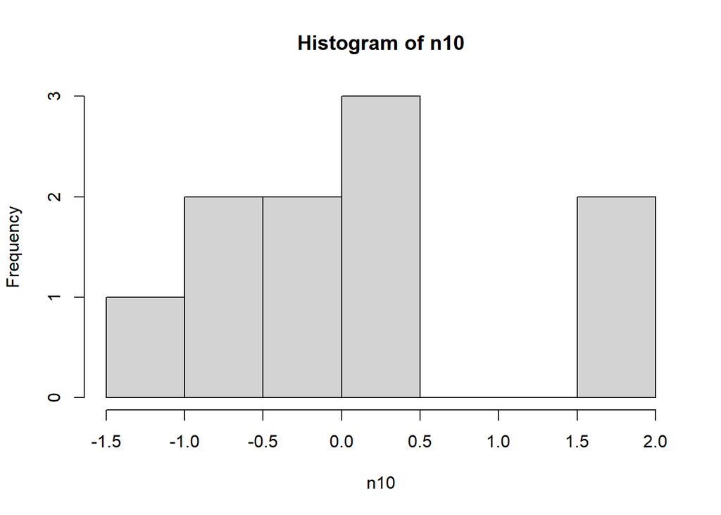

```r
# For n = 10
hist(n10)
```

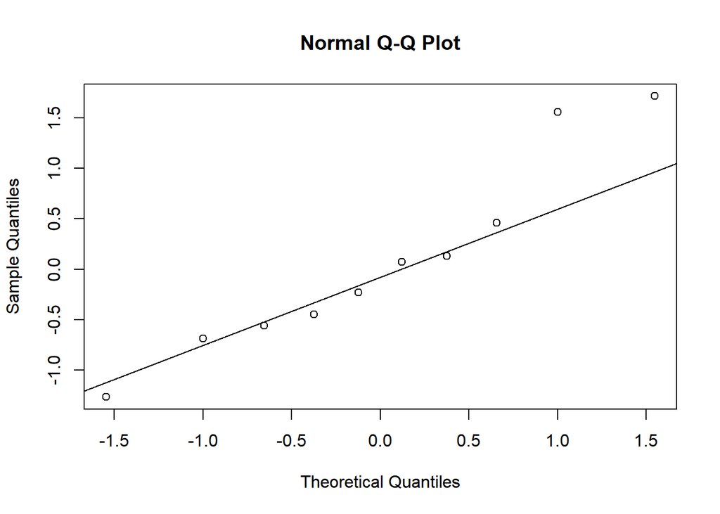

```r
{
qqnorm(n10)
qqline(n10)
}
```

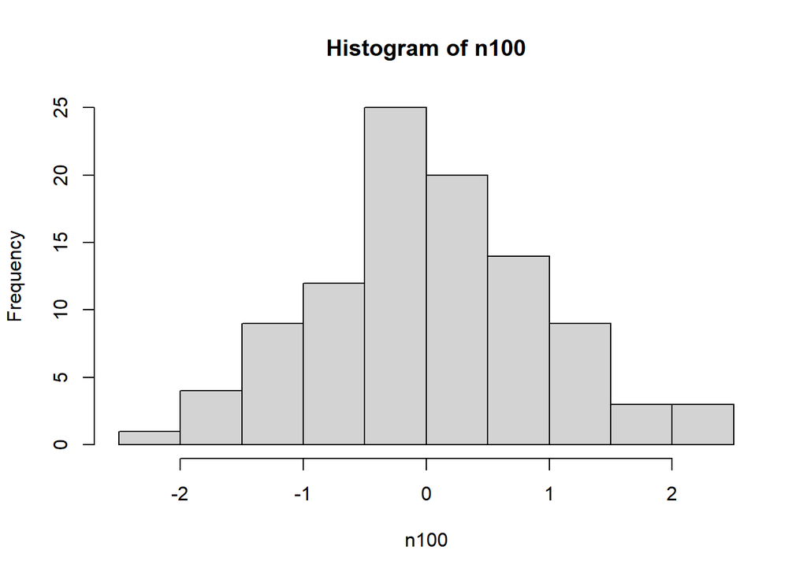

```r
# For n = 100
hist(n100)
```

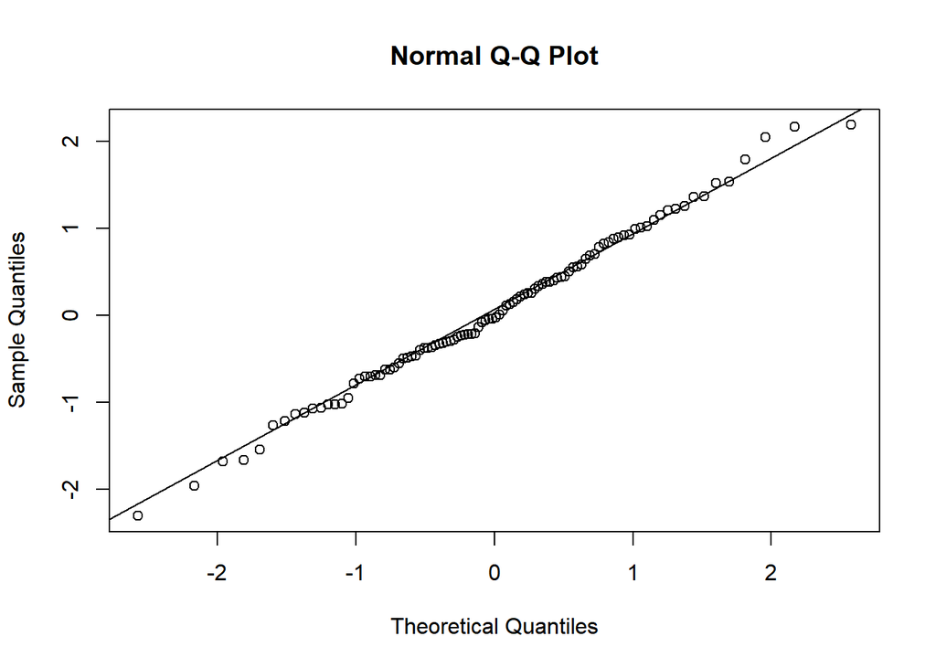

```r
{
qqnorm(n100)
qqline(n100)
}
```

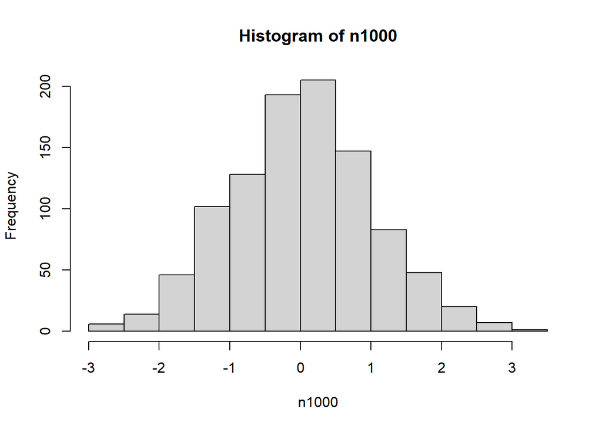

```r
# For n = 1000
hist(n1000)
```

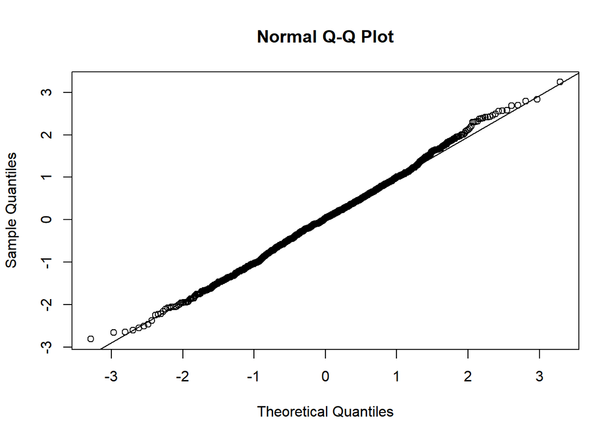

```r
{
qqnorm(n1000)
qqline(n1000)
}
```

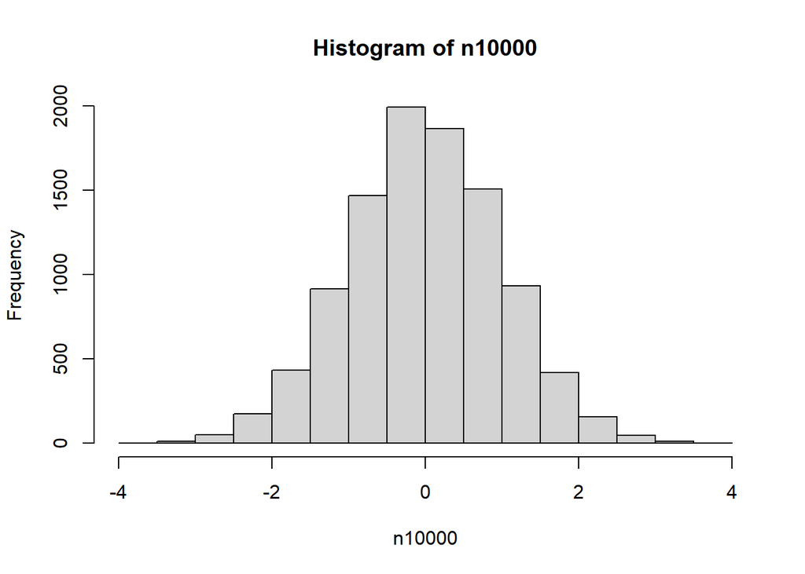

```r
# For n = 10000
hist(n10000)
```

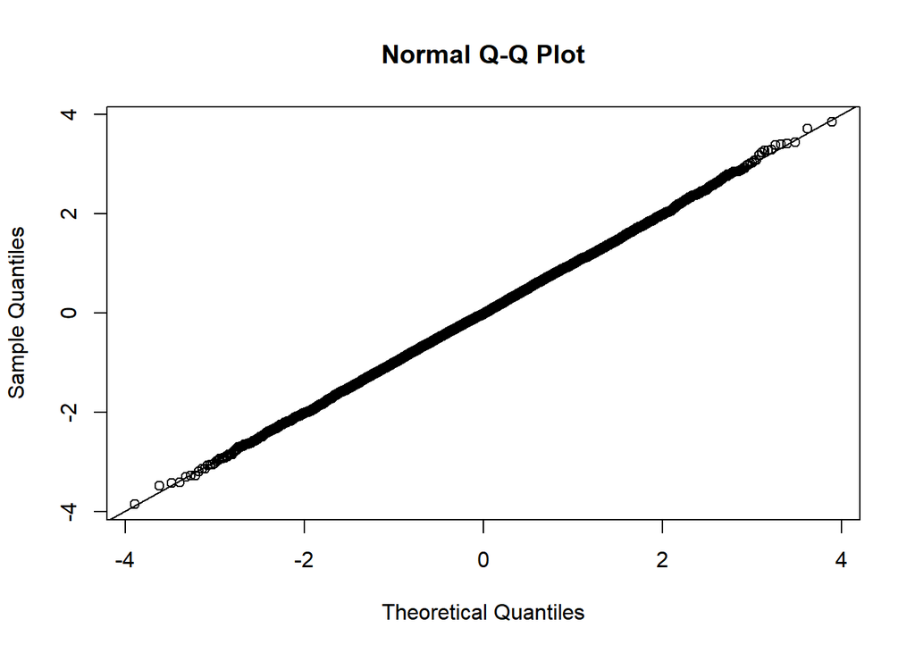

```r
{
qqnorm(n10000)
qqline(n10000)
}
```

\

We can see as our sample size $n$ increases, our distributions become much more normal in appearence!

### 3. Load the data given in the file **student.csv**. Construct a histogram and a normal probability plot of (a) students’ height and (b) students’ pulse. Would you agree with the statement that the data was generated from a normally distributed random variable? Why or why not?

```r
# Make sure your data is placed in the right folder!
student <- read.csv("student.csv")

# Head() function helps us print the first five rows of the data, for preview
head(student)
```

```
##   height hsGPA pulse
## 1   70.0  3.20    27
## 2   62.0  3.93    64
## 3   72.0  3.84    60
## 4   68.5  3.80    72
## 5   68.0  3.85    60
## 6   70.0  3.48    80
```

```r
# Great way to get a quick understanding of the data
summary(student)
```

```
##      height          hsGPA           pulse
##  Min.   :55.00   Min.   :2.600   Min.   : 27.00
##  1st Qu.:65.00   1st Qu.:3.500   1st Qu.: 64.00
##  Median :68.00   Median :3.750   Median : 72.00
##  Mean   :67.99   Mean   :3.653   Mean   : 74.83
##  3rd Qu.:71.00   3rd Qu.:3.890   3rd Qu.: 80.00
##  Max.   :80.00   Max.   :4.500   Max.   :160.00
```

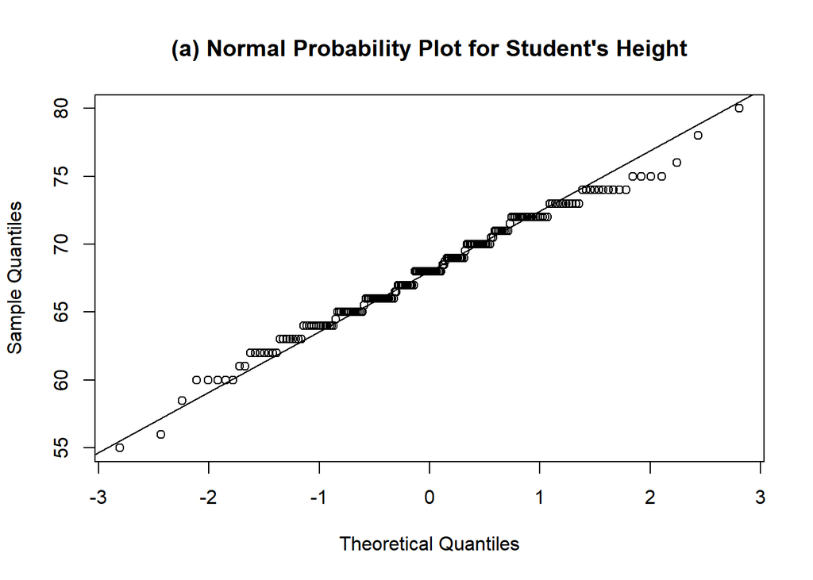

```r
# (a)
# Curly brackets help if you get an error trying to run one line at a time
{
qqnorm(student$height, main = "(a) Normal Probability Plot for Student's Height")
qqline(student$height)
}
```

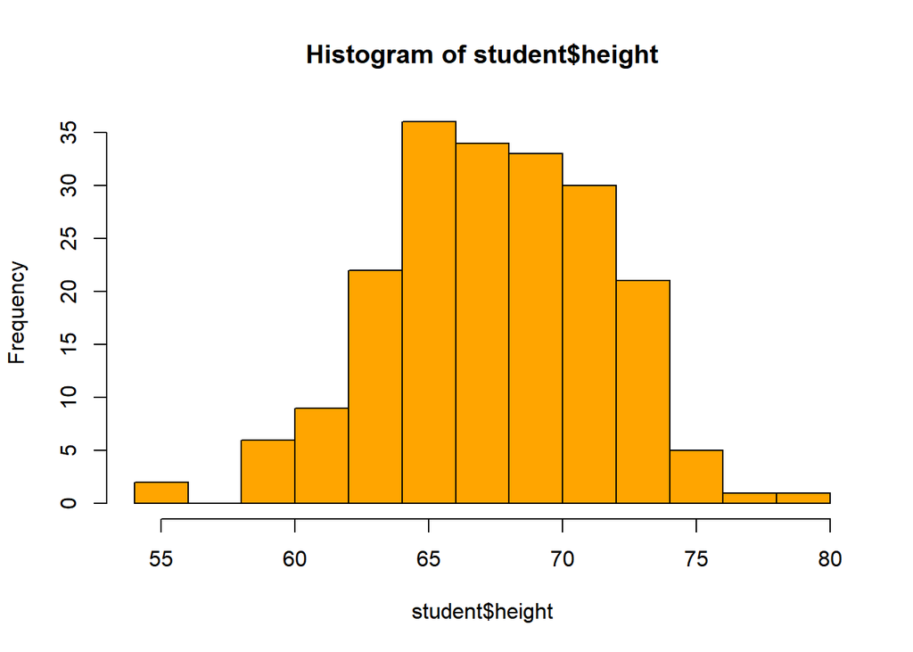

```r
hist(student$height, col = "orange")
```

Most of the points match up along a straight line. It suggests students heights are approximately normally distributed.

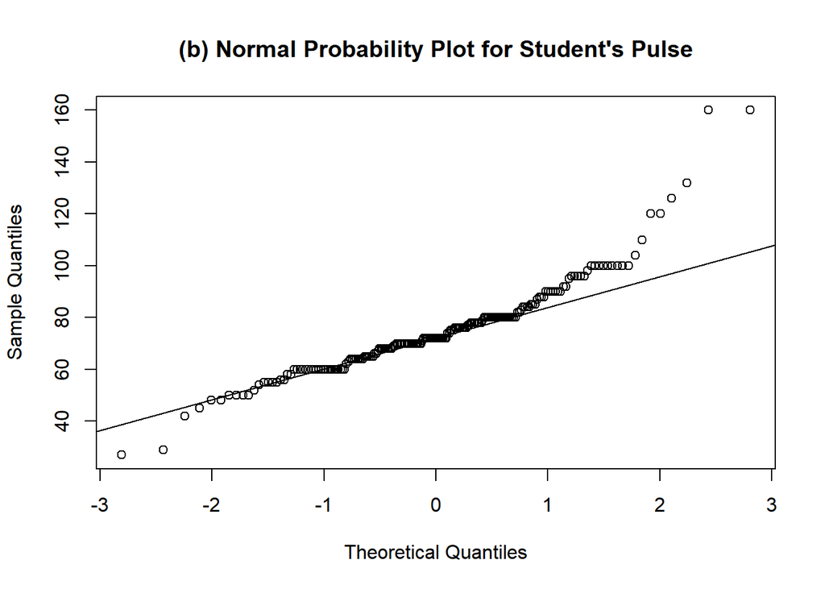

```r
# (b)
{
qqnorm(student$pulse, main = "(b) Normal Probability Plot for Student's Pulse")
qqline(student$pulse)
}
```

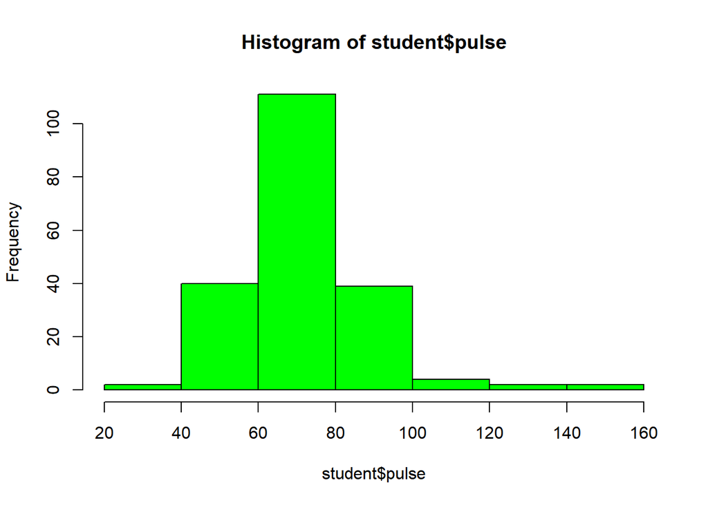

```r
hist(student$pulse, col = "green")
```

Confused on how to interpret a QQplot? Here is a great Stack Exchange page [here](https://stats.stackexchange.com/questions/101274/how-to-interpret-a-qq-plot).

## Bonus - Changing your RStudio Theme

You can customize your RStudio color layout with built-in RStudio themes! Here is how to do it.

- On the top left, click on **Tools**
- Scroll down to **Global Options**
- On the left, click on the **Appearence** option
- Scroll through the list of **Editor Themes** and click **Apply** once you have chosen one. Once you do, your RStudio will have a new look! If you would like to get into the spirit of Halloween, I recommend the “Merbivore” theme.